# Quick summary CY2021

##### Summary of CY VAA data after the first couple of days.

##### The total N after removal of invalid entries and a very light clean (>100 seconds) is: `17611` users.

## Descriptives

Here we use the full *choose4cyprus* sample (e.g. including undecided voters etc.,).

### Voting intentions in 2021 based on previous voting in the 2016 election

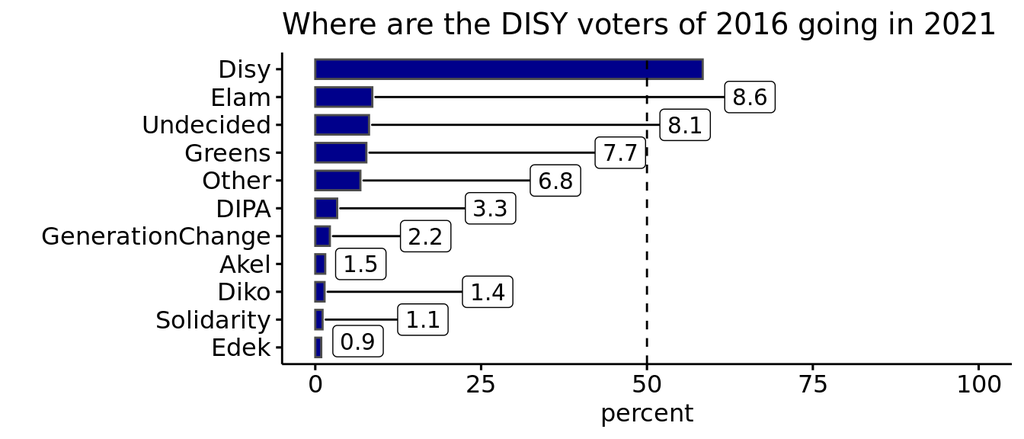

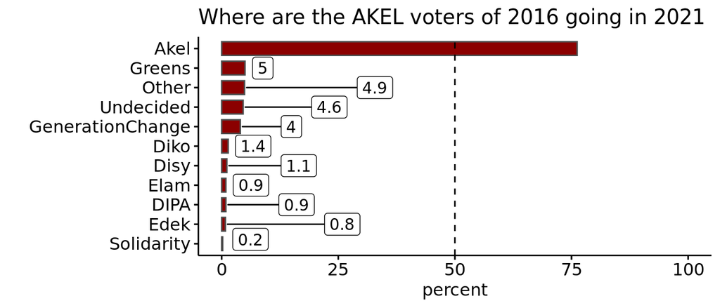

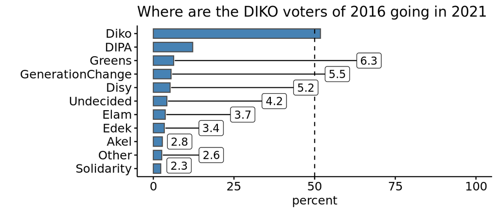

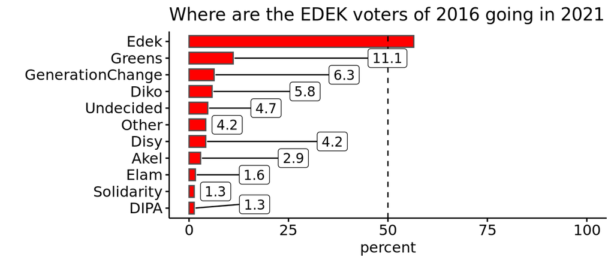

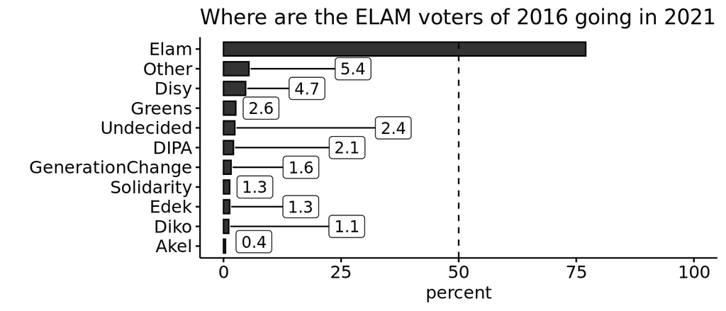

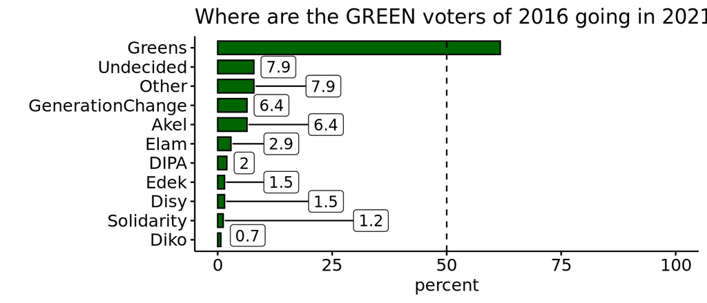

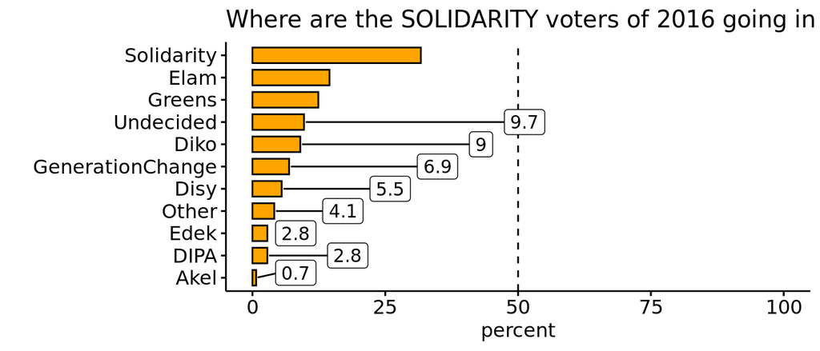

### Average self-placement on identity (grouped by voting intetion)

The three identities measured on 0:10 scale are: Cypriot, Greek, and European. Interesting how party supporters *pull* and *push* their Cypriot and Greek identities. A comparison of AKEL and ELAM is revealing here.

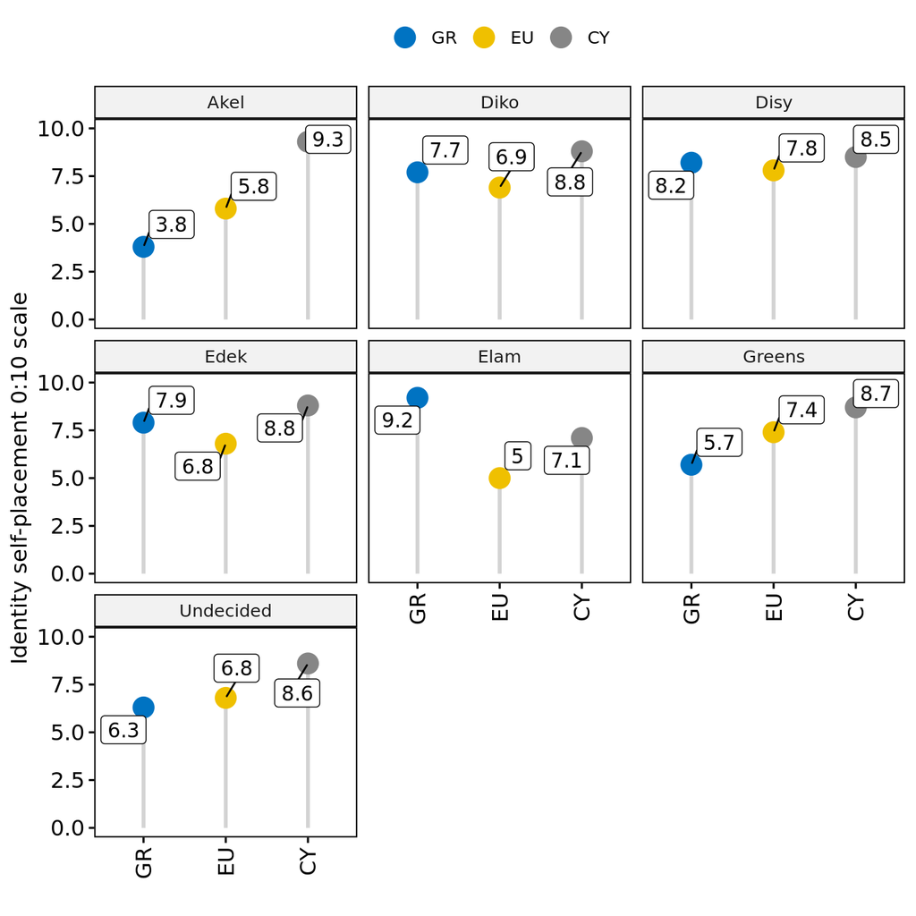

### Average self-placement on three issue scales (grouped by voting intetion)

The three issues measured on a 0:10 scale are:

- Social: 0 = Socially Liberal / 10 = Socially Conservative
- Eco: 0 = Left on the economy / 10 = Right on the economy .
- CYProblem: 0 = Against Federal solution / 10 = In favour of Federal solution

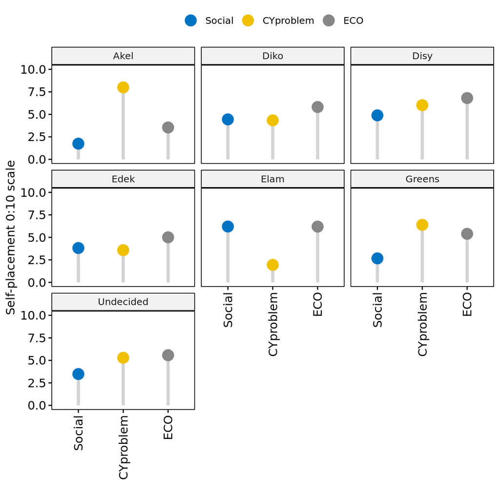

## Objective vs Subjective placements in Two-Dimensional map

Here we compare a so-called “Objective” placement and “Subjective”placements. Objective placements are derived from the answers to specific policy questions, for instance all the questions related to the CY-problem. A scale can then be formed based on the answers to these questions (there were 5 policy questions on the CY-problem). Subjective placements, on the other hand, are based on the respondents’ answer to a single self-placement question, e.g. an left/right question would take the following form: Where would you positions yourself on a 0:10 scale, where 0 means Left and 10 means Right?).

Like many other European countries, the Cypriot political space is structured around two main axes of political conflict. The first axis is a traditional Left vs. Right with respect to the Economy. The Left pole of the axis favours state intervention in the economy (e.g. higher taxes and more spending) while the Right pole prefers the opposite (e.g. lower taxes, less regulation and welfare spending).

A new dimension of political conflict over cultural identity issues has emerged in many European countries. Generally, the poles on this newer axis are clustered around “cultural demarcation” on one side (patriotic/nationalist while favouring more socially conservative/traditional values) and on the other pole a cultural integration pole that is more open to multiculturalism and socially more tolerant of alternative lifestyles). Not surprisngly, the CY-problem maps onto this cultural identity axis.

In the plot below Cypriot voter (based on their voting intention for each party) are placed according to how they answered policy questions -the Objective placement- and how they self-placed themselves on the two 0:10 scales, the Subjective placement. The dots are the Objective placement and the Triangle is the Subjective placement. Generally voters are more left-wing and less progressive based on their Objective answer patterns than they are in their Subjective self-placements. Although the distances aren’t so large as can be seen by the lines connecting the dots and triangles. The distance between Objective and Subjective placements is shortest for Disy voters, while Elam voters have a bigger dissonance between where they stand and where they think they stand.

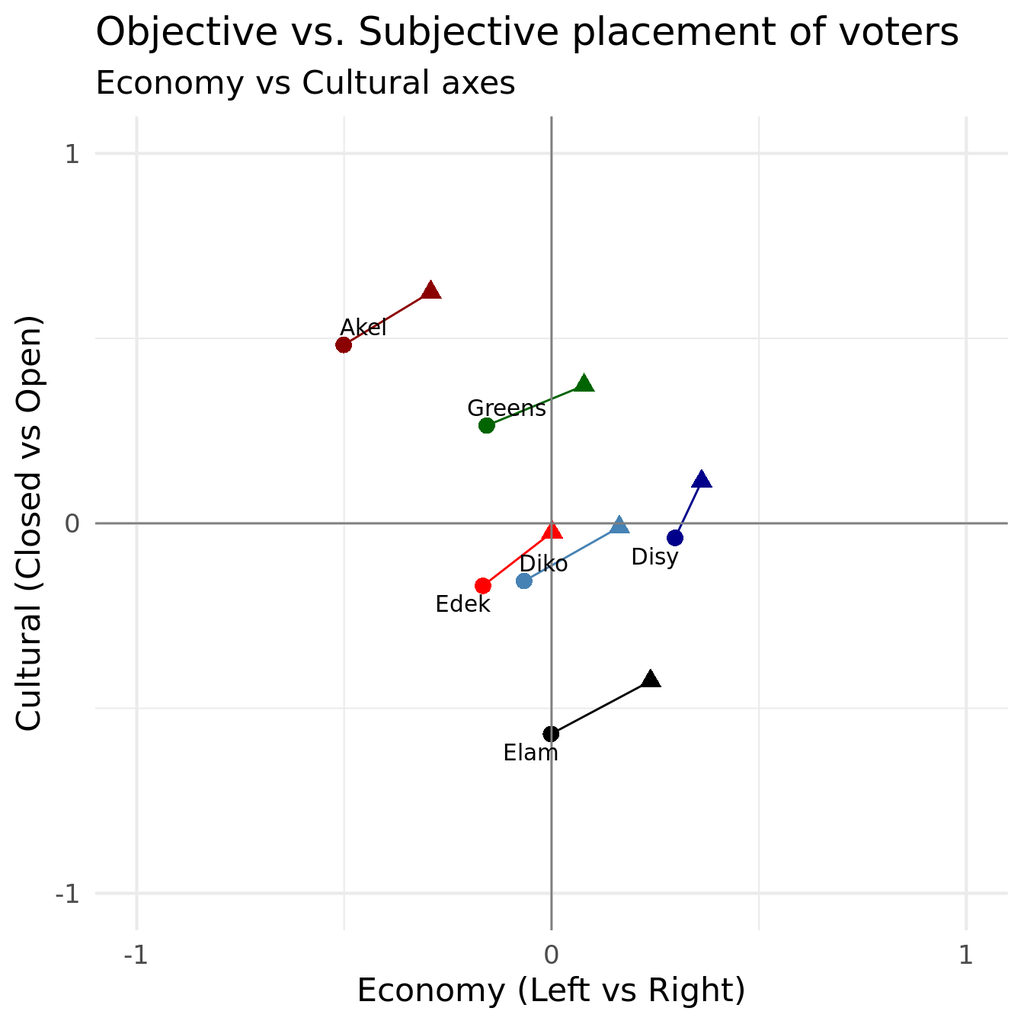

## Likert Plots (useful for viewing polarising items)

The plots are useful for viewing the policy items on which the APP is based. It is the answers to the 21 policy items that is used to match the respondent to the parties.

We have quite a balanced sample in terms of ideological preferences (almost identical AKEL and DISY numbers). So there’s not much need of further preprocessing to get an idea of political polarisation.

There are quite a few polarising questions, ie items that generate bimodal type distributions (agree vs disagree), such as item 16.

## Examples of polarising questions (ie., electorate divided)

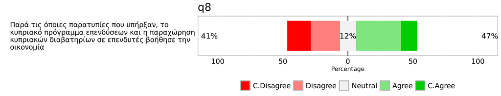

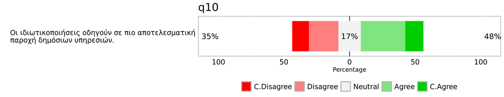

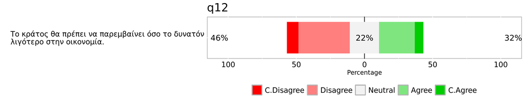

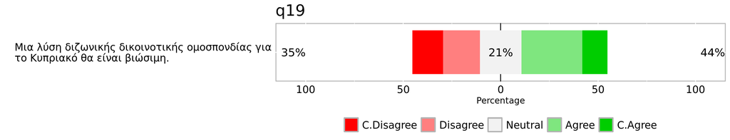

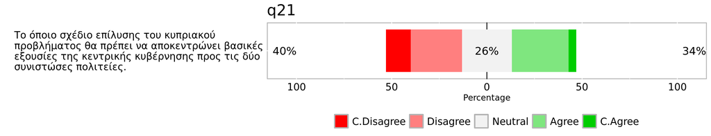

## Examples of Non-polarising questions (high consensus among electorate )

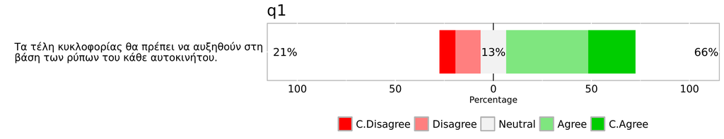

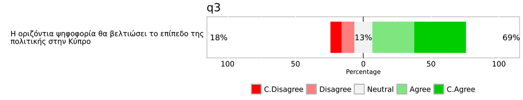

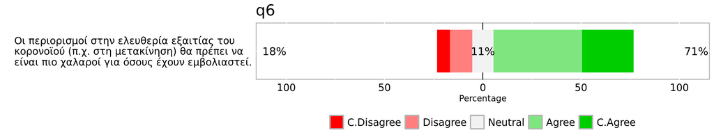

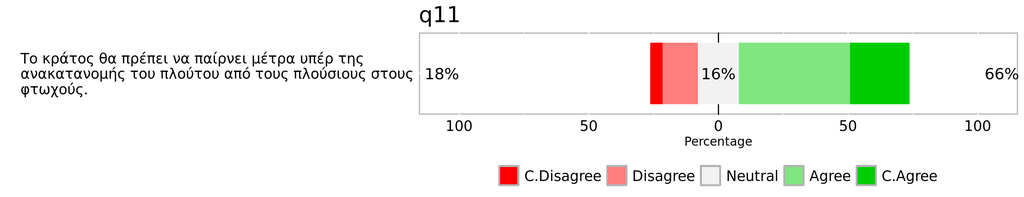

## Other examples (no distinctive patterns)

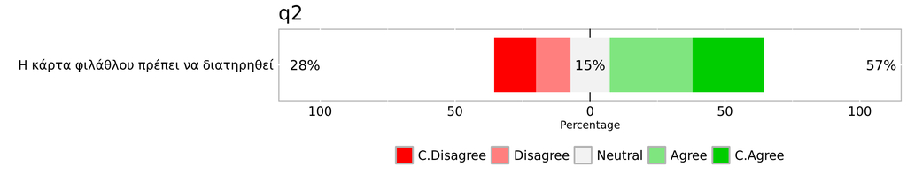

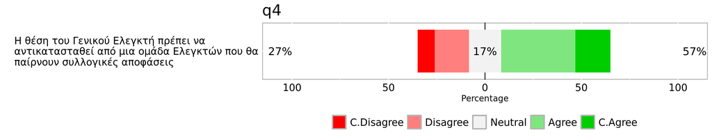

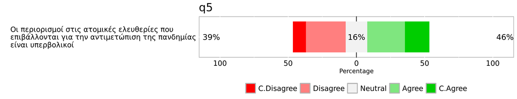

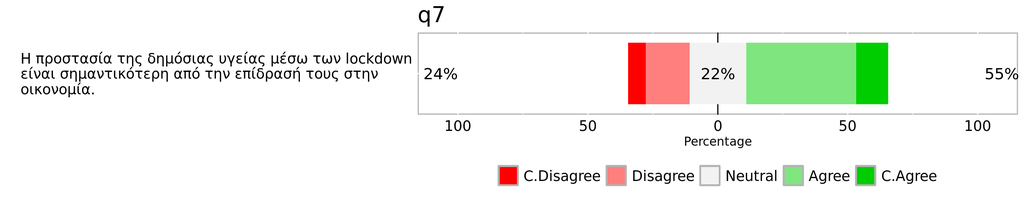

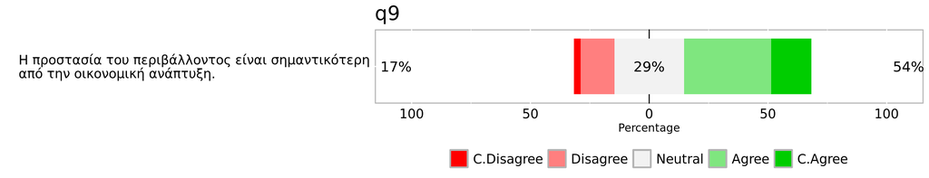

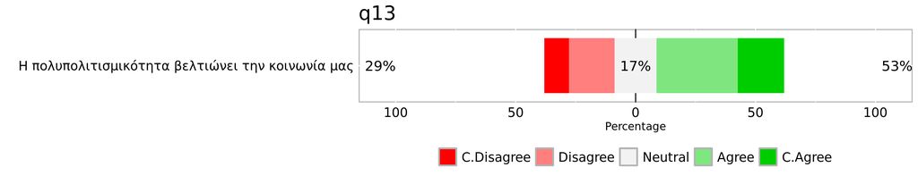

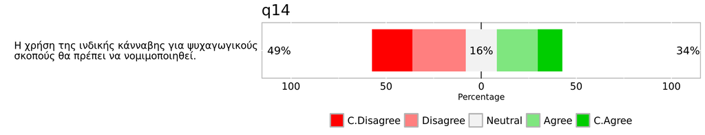

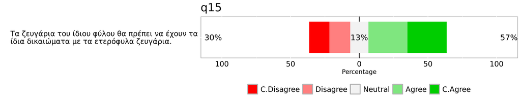

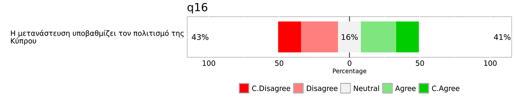

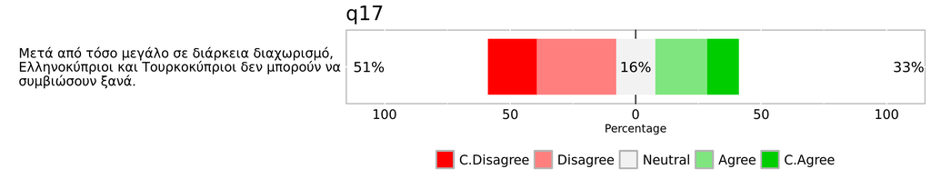

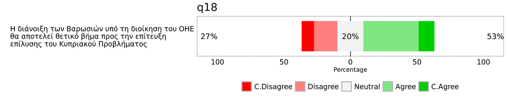

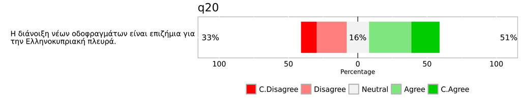